# Data Import and EDA in R

Michael McDonagh (2392623)

2026

## 0. Introduction

In this file we will import the dataset, perform some Exploratory Data Analysis on it and export half-cleaned full, training and test datasets for later use to fit classification models.

We are pulling all our data from https://football-data.co.uk/data.php, a site containing results, match statistics and betting odds since the 2003/2004 season, and basic stats since the second Premier League season in 1993/94. The website states that the data is free to use for private individuals, but not for commercial use (including products trained on the data). The website also contains data for other countries’ leagues, a collection of betting articles and various other resources.

We won’t go through the names and meanings of all of the recorded variables, but they can be viewed here https://football-data.co.uk/notes.txt

Packages to load in order to run the file:

```r
library(gplots)
```

## 1. Data Import

First we download all of the files that we will be using. We chose to take all of the data for each of the four English leagues from the 2003/2004 season onwards. This was motivated by this being the first season where the website had recorded any bookmakers’ odds. With one of our ideas to use the betting odds to improve the classifiers’ performances, this felt like a natural cutoff point. While there are an increasing number of variables that are recorded season upon season, the only requirement to be downloaded was for any betting odds to be one of them.

Getting the Excel files from the website:

```r
if(!dir.exists(file.path("..", "data"))){
  dir.create(file.path("..", "data"))
}

years<-2003:2025

# Splitting up the leagues

leagues<-c(
  E0 = "Premier_League",
  E1 = "Championship",
  E2 = "League_1",
  E3 = "League_2"
)

for(year in years){
  season<-paste0(
    substr(year, 3, 4),
    sprintf("%02d", (year+1) %% 100)
  )

  for(league_code in names(leagues)){
    league_name<-leagues[[league_code]]


    file_name<-paste0(league_name, "_data_", season, ".csv")
    file_path<-file.path("..", "data", file_name)

# Only downloading if not already there

    if(!file.exists(file_path)){
      url<-paste0("https://football-data.co.uk/mmz4281/", season, "/", league_code, ".csv")
      message("Downloading", file_name)
      download.file(url, file_path)
    }
    else{
      message("Already exists, skipping", file_name)
    }
  }

}
```

[output not shown]

[output not shown]

[output not shown]

[output not shown]

[output not shown]

[output not shown]

[output not shown]

[output not shown]

[output not shown]

[output not shown]

[output not shown]

[output not shown]

[output not shown]

[output not shown]

[output not shown]

[output not shown]

[output not shown]

[output not shown]

[output not shown]

[output not shown]

[output not shown]

[output not shown]

[output not shown]

[output not shown]

[output not shown]

[output not shown]

[output not shown]

[output not shown]

[output not shown]

[output not shown]

[output not shown]

[output not shown]

[output not shown]

[output not shown]

[output not shown]

[output not shown]

[output not shown]

[output not shown]

[output not shown]

[output not shown]

[output not shown]

[output not shown]

[output not shown]

[output not shown]

[output not shown]

[output not shown]

[output not shown]

[output not shown]

[output not shown]

[output not shown]

[output not shown]

[output not shown]

[output not shown]

[output not shown]

[output not shown]

[output not shown]

[output not shown]

[output not shown]

[output not shown]

[output not shown]

[output not shown]

[output not shown]

[output not shown]

[output not shown]

[output not shown]

[output not shown]

[output not shown]

[output not shown]

[output not shown]

[output not shown]

[output not shown]

[output not shown]

[output not shown]

[output not shown]

[output not shown]

[output not shown]

[output not shown]

[output not shown]

[output not shown]

[output not shown]

[output not shown]

[output not shown]

[output not shown]

[output not shown]

[output not shown]

[output not shown]

[output not shown]

[output not shown]

[output not shown]

[output not shown]

[output not shown]

[output not shown]

Next creating a compiled data frame: all 4 leagues across all 23 seasons.

```r
files<-list.files(
  file.path("..", "data"),
  pattern = "\\.csv$",
  full.names = TRUE
)

data_list<-list()

for(i in seq_along(files)){
  df<-read.csv(files[i])

# This deals with a bug in the data. Some rows of certain seasons had empty strings,
# which caused additional matches to be added with no information.
  df<-df[!is.na(df$Date) & df$Date!="", ]

  file_name<-basename(files[i])

# This creates a Season variable, by recording the years from the file name
  df$Season<-substr(
    file_name,
    nchar(file_name)-7,
    nchar(file_name)-4
  )

# Likewise this creates a League variable
  if(grepl("Premier_League", file_name)){
    df$League<-"Premier League"
  }
  else if(grepl("Championship", file_name)){
    df$League<-"Championship"
  }
  else if(grepl("League_1", file_name)){
    df$League<-"League 1"
  }
  else if(grepl("League_2", file_name)){
    df$League<-"League 2"
  }

  data_list[[i]]<-df
}

# This ensures that the dimensions of all of the data are the same by creating N/A columns for variables
# that aren't recorded in certain seasons
all_columns<-unique(unlist(lapply(data_list, names)))
data_list<-lapply(data_list, function(df){
  missing_columns<-setdiff(all_columns, names(df))
  df[missing_columns]<-NA
  df<-df[all_columns]
  return(df)
})

# Creating the data frame
data<-do.call(rbind, data_list)
```

Let’s see the first few rows:

```r
head(data, 4)
```

```
##   Div     Date HomeTeam       AwayTeam FTHG FTAG FTR HTHG HTAG HTR
## 1  E1 09/08/03 Bradford        Norwich    2    2   D    0    1   A
## 2  E1 09/08/03  Burnley Crystal Palace    2    3   A    2    2   D
## 3  E1 09/08/03    Derby          Stoke    0    3   A    0    2   A
## 4  E1 09/08/03  Ipswich        Reading    1    1   D    0    0   D
##           Referee HS AS HST AST HF AF HC AC HY AY HR AR B365H B365D B365A  GBH
## 1 Scott Mathieson 16  5   9   3  7 14  8  5  1  2  0  0 2.375  3.20 2.625 2.40
## 2           C Foy  7  6   2   2 15 17  6  1  2  2  0  2 2.250  3.25 2.750 2.25
## 3     Howard Webb 13 11   5   7 11 19  6  5  2  2  0  0 1.800  3.25 4.000 1.80
## 4        B Curson 13  7   4   4  8 20  2  6  1  3  0  1 1.833  3.25 3.750 1.90
##    GBD  GBA  IWH IWD IWA   LBH  LBD  LBA  SOH  SOD  SOA  SBH  SBD  SBA  WHH
## 1 3.20 2.70 2.20 3.1 2.8 2.400 3.25 2.50 2.38 3.20 2.63 2.37 3.20 2.62 2.30
## 2 3.20 2.90 2.30 3.1 2.6 2.200 3.25 2.75 2.20 3.25 2.80 2.20 3.20 2.87 2.25
## 3 3.25 4.15 1.75 3.3 3.8 1.800 3.20 4.00 1.73 3.25 4.33 1.72 3.25 4.33 1.72
## 4 3.25 3.75 1.80 3.3 3.6 1.909 3.25 3.40 1.80 3.25 4.00 1.80 3.25 4.00 1.83
```

[output cut: 70 more lines]

Exporting so that other group members can access: (I’ve made this into a comment so it doesn’t recreate an identical Excel file that overwrites itself each times the file is run)

```r
#write.csv(data, "../processed-data/football_data_halfclean.csv", row.names = FALSE)
```

## 2. EDA

Now we will use our ‘half-clean’ dataset to perform some Exploratory Data Analysis. Firstly, we might want to investigate how similar the Premier League data is to that of the lower leagues, and it would be useful to get some visualisation for this. To do this, we will create tables showing how the outcomes H (Home Win), D (Draw), and A (Away Win) are distributed for each league over the 23 seasons:

```r
results_proportions<-prop.table(table(data$FTR, data$League), margin = 2)
results_proportions
```

```
##
##     Championship  League 1  League 2 Premier League
##   A    0.2920605 0.2993463 0.3053878      0.2980549
##   D    0.2735507 0.2644292 0.2725683      0.2470252
##   H    0.4343888 0.4362245 0.4220439      0.4549199
```

We can plot each of the columns on a bar chart:

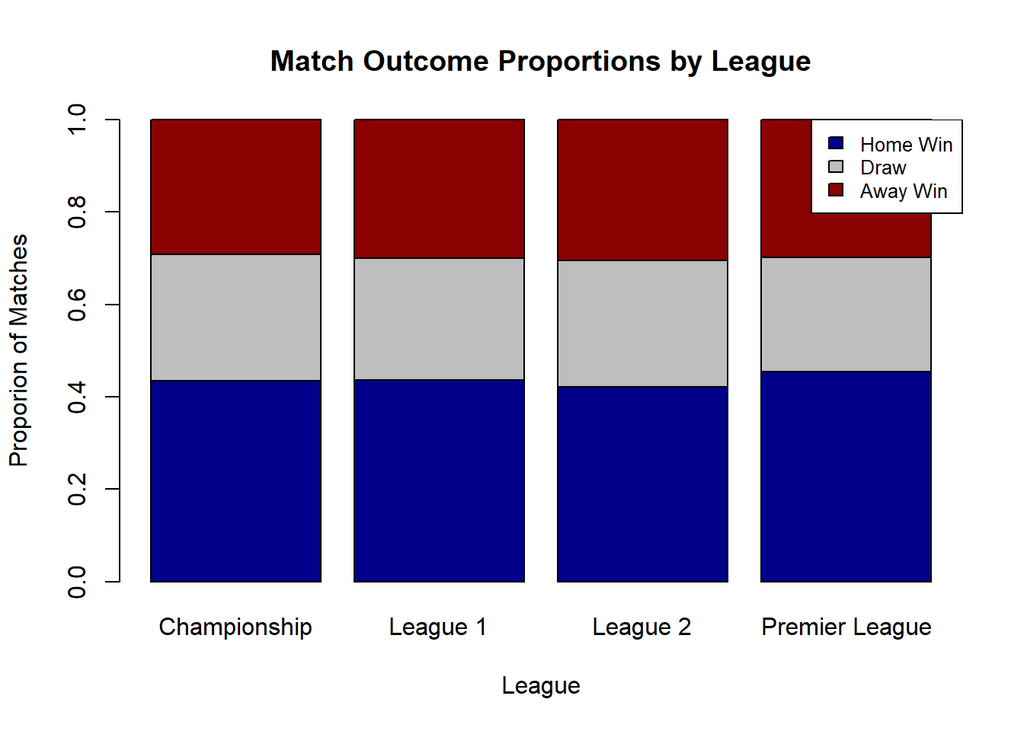

```r
barplot(
  results_proportions[c("H","D","A"), ],
  beside = FALSE,
  col=c("darkblue", "grey", "darkred"),
  ylim=c(0,1),
  main="Match Outcome Proportions by League",
  xlab = "League",
  ylab="Proporion of Matches"
)
legend("topright",
       legend = c("Home Win", "Draw", "Away Win"),
       fill=c("darkblue", "grey", "darkred"),
       cex=0.8)
```

This shows that the leagues have largely similar distributions of outcomes between these seasons, which suggests it may be possible to use the data for predictions across division.

The main noticeable difference between the Premier League and the lower leagues is that there is a lower proportion of draws in the top league - and this deficit seems to be almost entirely made up in a higher proportion of Home wins. This could suggest that having the home advantage may have a stronger effect that tips a draw into a win for the home team, more times on average in the top division.

But this doesn’t tell the full tale - as it’s an aggregated proportion over 23 years. It could be that in the seasons themselves, vastly different things were happening in each league. Therefore we will plot line graphs for these outcome proportions for each league over time:

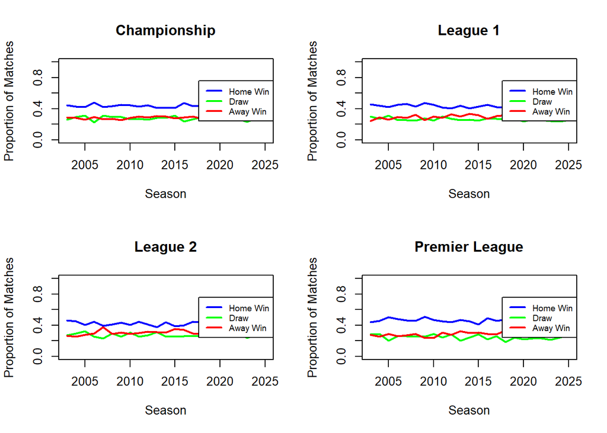

```r
seasons<-sort(unique(data$Season))
season_years<-2003:(2003 + length(seasons) - 1)
leagues<-unique(data$League)

par(mfrow=c(2,2))

for(league in leagues){
  league_data<-data[data$League==league, ]
  proportions<-sapply(seasons, function(s){
    matches<-league_data[league_data$Season==s, "FTR"]
    prop.table(table(factor(matches, levels = c("H", "D", "A"))))
  })
  matplot(season_years, t(proportions),
        type="l", lty = 1, lwd=2,
        col=c("blue", "green", "red"),
        ylim=c(0,1),
        main = league,
        xlab="Season", ylab = "Proportion of Matches")
  legend("right", legend = c("Home Win", "Draw", "Away Win"),
       col = c("blue", "green", "red"),
       lty=1, lwd=2, cex=0.7)
}
```

From these we can see that even with a few slight seasonal fluctuations, the pattern across all leagues was broadly similar. The Home win took the largest chunk of the overall proportion across pretty much all seasons for each league, with the Draw and Away win amounts being quite similar in each.

Another thing to look into is even if the outcome is the same, how did the scores compare? For example a full time score 3-3 is much different to Nil-Nil - it tells us that the match was much more open and attacking from both sides, which let goals flow in on either end. Thus we will create a table showing the average Home/Away goals and Home minus Away goal difference per game:

```r
goal_averages<-aggregate(cbind(FTHG, FTAG) ~ League, data = data, FUN=mean, na.rm=TRUE)
names(goal_averages)<-c("League", "Average Home Goals", "Average Away Goals")
goal_averages$`Average H-A Goal Difference`<-goal_averages$`Average Home Goals` - goal_averages$`Average Away Goals`

goal_averages
```

```
##           League Average Home Goals Average Away Goals
## 1   Championship           1.431317           1.124291
## 2       League 1           1.450415           1.166693
## 3       League 2           1.402098           1.145264
## 4 Premier League           1.539474           1.192449
##   Average H-A Goal Difference
## 1                   0.3070258
## 2                   0.2837213
## 3                   0.2568341
## 4                   0.3470252
```

Like with the outcomes we can put this into bar charts:

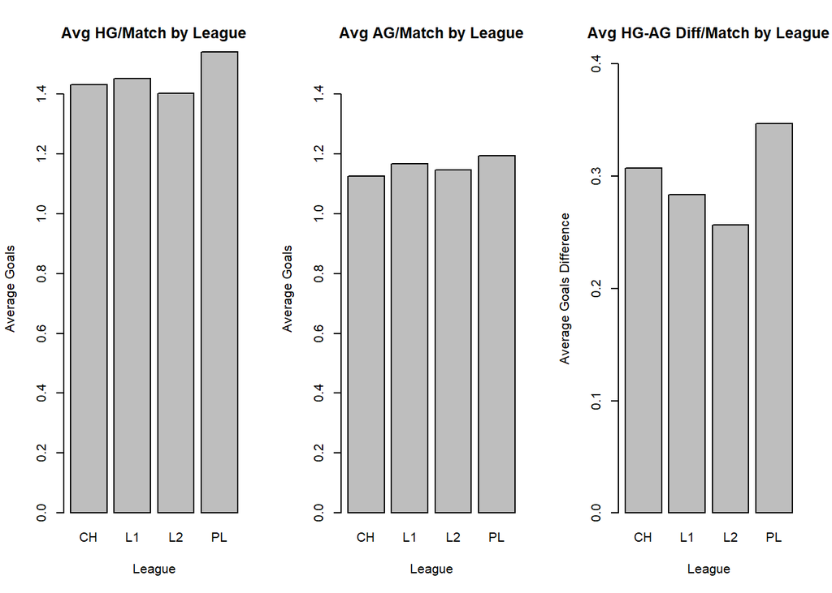

```r
par(mfrow=c(1,3))
league_labels<-c("CH", "L1", "L2", "PL")

barplot(goal_averages$`Average Home Goals`,
        names.arg = league_labels,
        main = "Avg HG/Match by League",
        xlab = "League",
        ylab = "Average Goals",
        ylim = c(0, 1.5))
barplot(goal_averages$`Average Away Goals`,
        names.arg = league_labels,
        main = "Avg AG/Match by League",
        xlab = "League",
        ylab = "Average Goals",
        ylim = c(0,1.5))
barplot(goal_averages$`Average H-A Goal Difference`,
        names.arg = league_labels,
        main = "Avg HG-AG Diff/Match by League",
        xlab = "League",
        ylab = "Average Goals Difference",
        ylim = c(0,0.4))
```

With both higher Home and Away goals than the others, the Premier League is the league with the biggest scorelines. However, the Home advantage still seems to be the biggest difference maker, as it actually still has the largest average difference in goals between the teams. In fact, one can see that the average H-A goal difference increases going up each rung of the league ladder - with the largest jump from the Championship to the PL.

This doesn’t prove that the PL is necessarily the ‘most attacking’. As each club will play each other twice per season; once Home and once Away, the higher Away goals could potentially be inflated by the stronger teams in the case that the Premier League has the largest ‘skill’ difference between its top dogs and the rest of the pack.

The more interesting variables included in the dataset include all of the many betting odds. Both Opening and Closing Odds are recorded for each bookmaker in each market. There are 3 main markets: 1x2 (the standard, where you just predict the result); Over/Under 2.5 total goals (as it sounds); and Asian Handicap (a bit more complicated, it gives the ‘better’ team a handicap to overcome).

We may want to see how the Opening and Closing Odds relate to each other across the dataset. There are a lot of betting sites, so for now we will only show the correlation plots for the Bet365 Opening and Closing outcomes for each of the three outcomes:

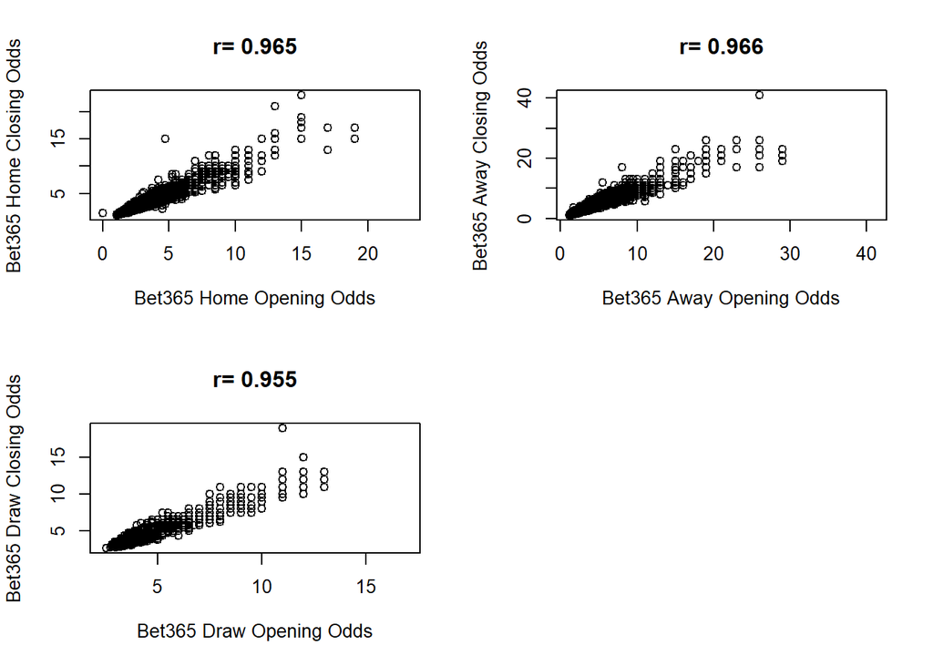

```r
par(mfrow=c(2,2))

plot(data$B365H, data$B365CH, xlab = "Bet365 Home Opening Odds", ylab = "Bet365 Home Closing Odds", main = (paste("r=", round(cor(data$B365H, data$B365CH, use = "complete.obs"), 3))))
plot(data$B365A, data$B365CA, xlab = "Bet365 Away Opening Odds", ylab = "Bet365 Away Closing Odds", main = (paste("r=", round(cor(data$B365A, data$B365CA, use = "complete.obs"), 3))))
plot(data$B365D, data$B365CD, xlab = "Bet365 Draw Opening Odds", ylab = "Bet365 Draw Closing Odds", main = (paste("r=", round(cor(data$B365D, data$B365CD, use = "complete.obs"), 3))))


par(mfrow=c(1,1))
```

Unsurprisingly, the Pearson Correlation Coefficient `r` is extremely high for all three cases, representing very strong positive correlation. We can plot a table for the full results with N the number of observations each value of `r` is calculated from:

```r
bookmakers<-c("B365", "BW", "IW", "WH", "VC", "PS", "BF", "BFD", "BFE", "BMGM", "BV", "CL", "LB", "X1XB")
outcomes<-c("H", "D", "A")
results<-data.frame()
for (company in bookmakers){
    for (outcome in outcomes){
        opening<-paste0(company, outcome)
        closing<-paste0(company, "C", outcome)
        valid<-complete.cases(data[, c(opening, closing)])
        results<-rbind(results, data.frame(
            Bookmaker=company,
            Outcome = outcome,
            Correlation = round(cor(data[[opening]][valid], data[[closing]][valid]), 3), N=sum(valid)
        ))
    }
}

bookmakers_AH<-c("B365", "P", "BFE")
outcomes_AH<-c("H", "A")
results_AH<-data.frame()
for (company in bookmakers_AH){
    for (outcomeAH in outcomes_AH){
        opening<-paste0(company, "AH", outcomeAH)
        closing<-paste0(company, "CAH", outcomeAH)
        valid<-complete.cases(data[, c(opening, closing)])
        results_AH<-rbind(results_AH, data.frame(
            Bookmaker=company,
            Outcome = outcomeAH,
            Correlation = round(cor(data[[opening]][valid], data[[closing]][valid]), 3), N=sum(valid)
        ))
    }
}


bookmakers_25O<-c("B365", "BFE")
results_25O<-data.frame()
for (company in bookmakers_25O){
  opening<-paste0(company, ".2.5")
  closing<-paste0(company, "C.2.5")
  valid<-complete.cases(data[, c(opening, closing)])
  results_25O<-rbind(results_25O, data.frame(
    Bookmaker=company,
    Outcome = "Over 2.5",
    Correlation = round(cor(data[[opening]][valid], data[[closing]][valid]), 3), N=sum(valid)
  ))
}


bookmakers_25U<-c("B365", "BFE")
results_25U<-data.frame()
for (company in bookmakers_25U){
  opening<-paste0(company, ".2.5.1")
  closing<-paste0(company, "C.2.5.1")
  valid<-complete.cases(data[, c(opening, closing)])
  results_25U<-rbind(results_25U, data.frame(
    Bookmaker=company,
    Outcome = "Under 2.5",
    Correlation = round(cor(data[[opening]][valid], data[[closing]][valid]), 3), N=sum(valid)
    ))
}

results$Market<-"1X2"
results_AH$Market<-"Asian Handicap"
results_25O$Market<-"Over/Under 2.5"
results_25U$Market<-"Over/Under 2.5"
all_results<-rbind(results, results_AH, results_25O, results_25U)
all_results<-all_results[, c("Market", "Bookmaker", "Outcome", "Correlation", "N")]
all_results
```

```
##            Market Bookmaker   Outcome Correlation     N
## 1             1X2      B365         H       0.965 13980
## 2             1X2      B365         D       0.955 13980
## 3             1X2      B365         A       0.966 13980
## 4             1X2        BW         H       0.965 13146
## 5             1X2        BW         D       0.961 13146
## 6             1X2        BW         A       0.969 13146
## 7             1X2        IW         H       0.967  8940
## 8             1X2        IW         D       0.967  8940
## 9             1X2        IW         A       0.975  8940
## 10            1X2        WH         H       0.965 11548
## 11            1X2        WH         D       0.966 11548
## 12            1X2        WH         A       0.975 11548
## 13            1X2        VC         H       0.942  9910
## 14            1X2        VC         D       0.959  9910
```

[output cut: 38 more lines]

The rest of the results mostly follow this behaviour - with the exception of the Asian Handicap odds for some reason. While they are a different type of betting odd to the standard, the intra-market relation should still be close, just as with the 1x2 and Over/Under 2.5 odds. We can investigate to see what is happening, using the Bet365 AH Home odds as an example:

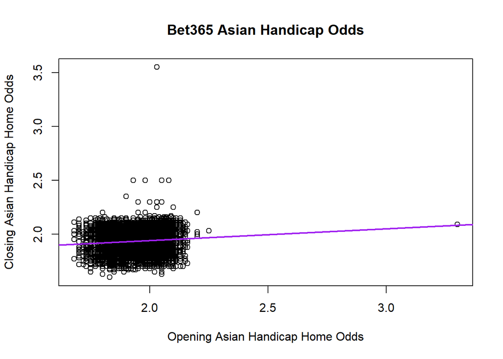

```r
valid_AH<-complete.cases(data[, c("B365AHH", "B365CAHH")])

plot(data$B365AHH[valid_AH],data$B365CAHH[valid_AH],
     xlab = "Opening Asian Handicap Home Odds",
     ylab = "Closing Asian Handicap Home Odds",
     main = "Bet365 Asian Handicap Odds")

abline(lm(data$B365CAHH[valid_AH] ~ data$B365AHH[valid_AH]), col = "purple", lwd = 2)
```

The data does look completely uncorrelated, which is strange, but nothing is going wrong with the calculation. This remains a question, but not one we will be needing to answer due to how we are going to create the training and test data sets.

## 3. Creating the Train and Test data

Now we will begin to remove some variables that we don’t want the classification models to use. The obvious ones include Full Time Home/Away goals, as in combination these just give the Full Time Result. Furthermore we don’t want any number of goals at Halftime to be shown either, as this gives too much information (as does the Halftime Result, clearly).

We decided to not include the Time of kickoff and name of the Referee as we don’t want to introduce unnecessary variance to any model which trains on these, in case there happens to be some association to match results.

Date and Season, and Division and League respectively overlap with each other. We want to consider the lower leagues as a full, combined dataset, which is why we remove their tags. Taking into account changes in the football landscape over time is a complex task, and when creating a model we don’t want to have to make any assumptions about dependence between the results across multiple seasons. So we will remove when the games were played and will treat each match as separate observation, without accounting for any such possible dependence.

Some less obvious variables we remove are the Home and Away Team names. This is to prevent the models from trying to learn which teams are stronger, which can change between seasons (which we’ve already removed).

‘X’ was a dummy variable that was N/A in all rows. Grouping it and all the other variables just mentioned:

```r
remove_vars_0<-c("Div", "Date", "HomeTeam", "AwayTeam", "Referee", "Time", "X", "Season", "League", "FTHG",
                 "FTAG", "HTAG", "HTHG", "HTR")
```

Now there are a lot of Betting Odds that we will remove. All summary statistics, including maximum and average odds, and the number of bookmakers to calculate the average odds, are removed as they are trivial to calculate.

Putting together all of the odds to remove:

```r
closing_odds<-grep("C(H|D|A)$|C\\.|CAH|AHCh", names(data), value=TRUE)
max_avg_odds<-grep("^(Max|Avg|BbMx|BbAv)", names(data), value=TRUE)
bookmaker_counts<-grep("^Bb(1X2|OU|AH)$", names(data), value=TRUE)
odds_to_remove<-unique(c(closing_odds, max_avg_odds, bookmaker_counts))
```

We can now combine all of the variables to remove:

```r
remove_vars_1<-unique(c(remove_vars_0, odds_to_remove))
remove_vars_1
```

```
##   [1] "Div"         "Date"        "HomeTeam"    "AwayTeam"    "Referee"
##   [6] "Time"        "X"           "Season"      "League"      "FTHG"
##  [11] "FTAG"        "HTAG"        "HTHG"        "HTR"         "VCH"
##  [16] "VCD"         "VCA"         "PSCH"        "PSCD"        "PSCA"
##  [21] "B365CH"      "B365CD"      "B365CA"      "BWCH"        "BWCD"
##  [26] "BWCA"        "IWCH"        "IWCD"        "IWCA"        "WHCH"
##  [31] "WHCD"        "WHCA"        "VCCH"        "VCCD"        "VCCA"
##  [36] "MaxCH"       "MaxCD"       "MaxCA"       "AvgCH"       "AvgCD"
##  [41] "AvgCA"       "B365C.2.5"   "B365C.2.5.1" "PC.2.5"      "PC.2.5.1"
##  [46] "MaxC.2.5"    "MaxC.2.5.1"  "AvgC.2.5"    "AvgC.2.5.1"  "AHCh"
##  [51] "B365CAHH"    "B365CAHA"    "PCAHH"       "PCAHA"       "MaxCAHH"
##  [56] "MaxCAHA"     "AvgCAHH"     "AvgCAHA"     "BFCH"        "BFCD"
##  [61] "BFCA"        "X1XBCH"      "X1XBCD"      "X1XBCA"      "BFECH"
##  [66] "BFECD"       "BFECA"       "BFEC.2.5"    "BFEC.2.5.1"  "BFECAHH"
##  [71] "BFECAHA"     "BFDCH"       "BFDCD"       "BFDCA"       "BMGMCH"
##  [76] "BMGMCD"      "BMGMCA"      "BVCH"        "BVCD"        "BVCA"
##  [81] "CLCH"        "CLCD"        "CLCA"        "LBCH"        "LBCD"
##  [86] "LBCA"        "BbMxH"       "BbAvH"       "BbMxD"       "BbAvD"
##  [91] "BbMxA"       "BbAvA"       "BbMx.2.5"    "BbAv.2.5"    "BbMx.2.5.1"
##  [96] "BbAv.2.5.1"  "BbMxAHH"     "BbAvAHH"     "BbMxAHA"     "BbAvAHA"
## [101] "MaxH"        "MaxD"        "MaxA"        "AvgH"        "AvgD"
## [106] "AvgA"        "Max.2.5"     "Max.2.5.1"   "Avg.2.5"     "Avg.2.5.1"
## [111] "MaxAHH"      "MaxAHA"      "AvgAHH"      "AvgAHA"      "Bb1X2"
## [116] "BbOU"        "BbAH"
```

Now creating the training and test data without columns of these variables:

```r
train_data<-data[
  data$League %in% c("Championship", "League 1", "League 2"),
  !names(data) %in% remove_vars_1,
  drop = FALSE
]

test_data<-data[
  data$League %in% c("Premier League"),
  !names(data) %in% remove_vars_1,
  drop = FALSE
]
```

As before, exporting so that other group members can access: (I’ve made this into a comment again for the same reason)

```r
#write.csv(train_data, "../processed-data/football_train_data.csv", row.names = FALSE)

#write.csv(test_data, "../processed-data/football_test_data.csv", row.names = FALSE)
```

## 4. Closing remarks and next steps

We end with some heat maps of the predictors that survived, and are in the current training and test data. Keep in mind that not necessarily all of them will be used, as we have to undergo missingness checks and decide on whether or not imputation is wanted/needed. This will show how the relationships they have with each other look:

```r
train_predictor_correlations <- cor(train_data[, !names(train_data) %in% "FTR", drop=FALSE],
                                    use = "pairwise.complete.obs")

test_predictor_correlations <- cor(test_data[, !names(test_data) %in% "FTR", drop=FALSE],
                                    use = "pairwise.complete.obs")

heatmap_colours <- colorRampPalette(c("yellow", "orange", "red"))(100)
```

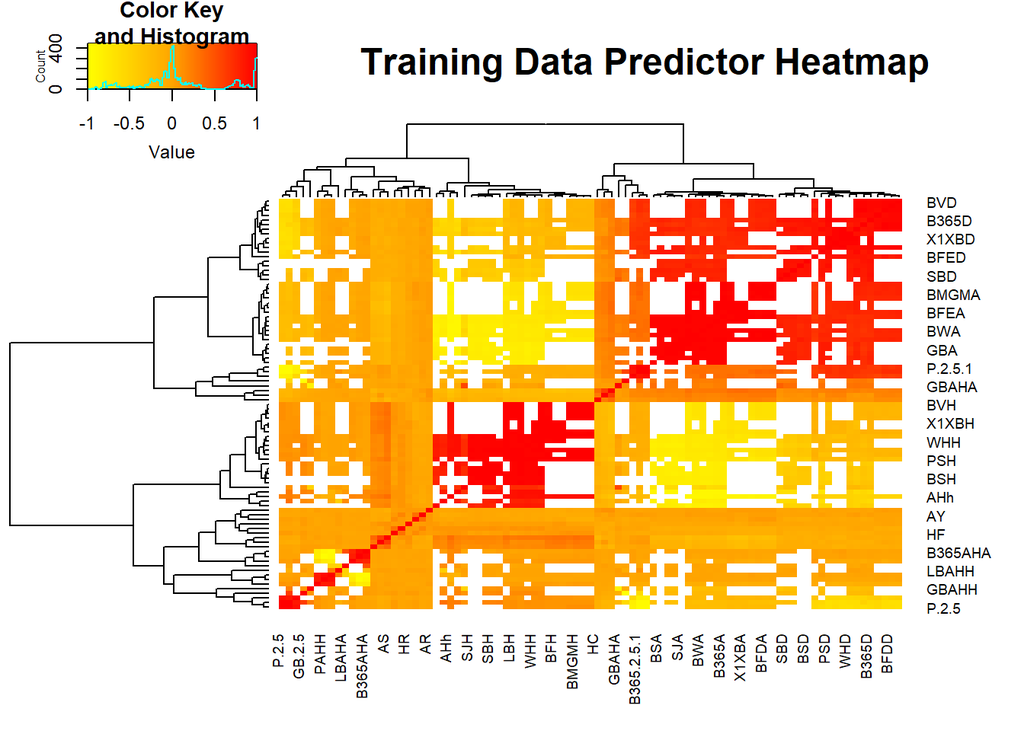

```r
heatmap.2(
  train_predictor_correlations,
  symm = TRUE,
  trace = "none",
  col = heatmap_colours,
  breaks = seq(-1, 1, length.out = 101),
  key = TRUE,
  main = "           Training Data Predictor Heatmap"
)
```

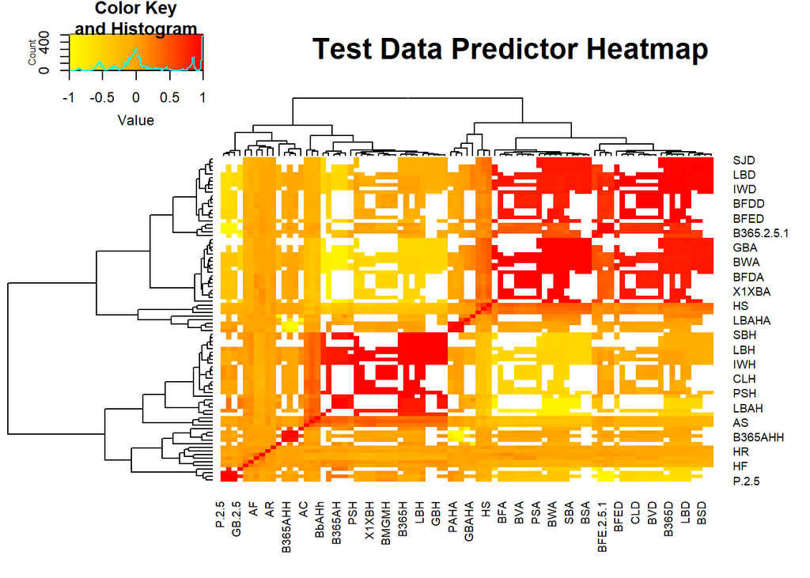

```r
heatmap.2(
  test_predictor_correlations,
  symm = TRUE,
  trace = "none",
  col = heatmap_colours,
  breaks = seq(-1, 1, length.out = 101),
  key = TRUE,
  main = "           Test Data Predictor Heatmap"
)
```

The predictors seem to interact in a broadly similar way across the training and test sets, though they are not completely identical.

In the following files we will go on to fit various classification models to the training data, and ultimately evaluate performance on the test data. Hopefully we can then decide on which method is best, and answer whether or not the lower leagues’ data is sufficient for training a classification model on for use in the Premier League.